# Week_3_Master_Class_Part2 : Distance Functions and Error Metrics

2023-11-20

## Distance Functions:

A metric or distance function is a function d(x,y) that defines the distance between elements of a set as a non-negative real number.

If the distance is zero, both elements are equivalent under that specific metric. Distance functions thus provide a way to measure how close two elements are, where elements do not have to be numbers but can also be vectors, matrices or arbitrary objects.

Distance functions are often used as error or cost functions to be minimized in an optimization problem.

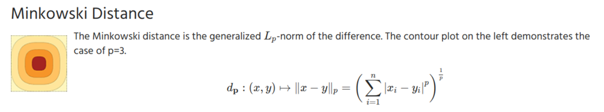

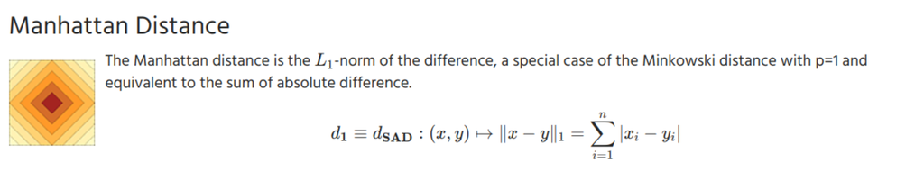

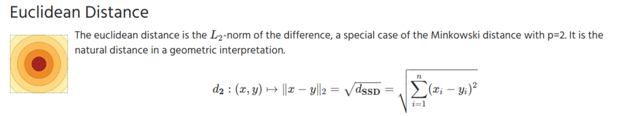

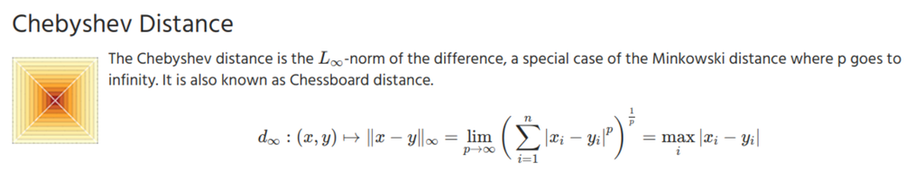

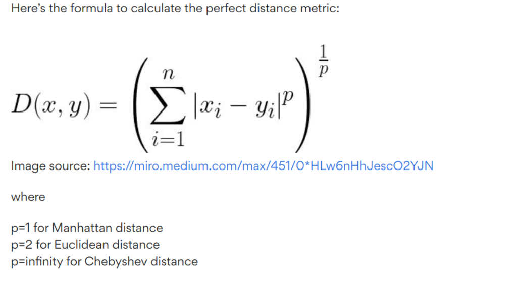

## Here is a summarized view of all the distance functions:

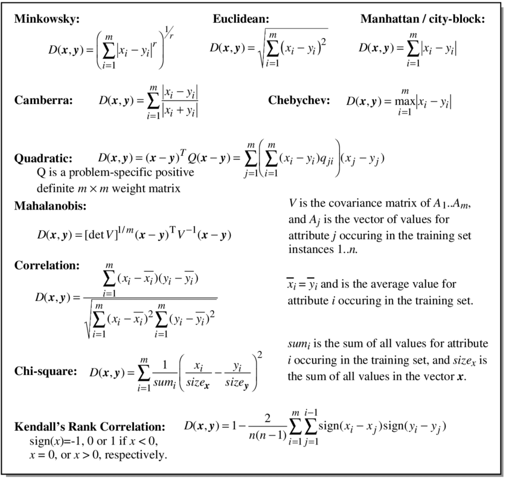

Distance_Functions

### Calculating Distances:

```r
# Define a general function to find the Minkowski distance between two points.
# Based on the value of 'p', the distance measure will change.

minkowski_distance <- function(x,y,p) {
        (sum(abs(x-y)^p))^(1/p)
}

# Manhattan distance: p = 1
# Euclidean distance: p = 2
```

## Illustrative Example to find distances:

```r
# Install and load necessary packages
#install.packages("caTools")  # For sample.split
#install.packages("MASS")     # For Boston dataset
#install.packages("caret")    # For RMSE calculation
#install.packages("glmnet")   # For linear regression model

library(caTools)
library(MASS)
library(caret)
library(glmnet)
# Load the Boston dataset (example dataset in MASS package)
data(Boston)

# Set a seed for reproducibility
set.seed(123)

# Split the data into training and testing sets
split <- sample.split(Boston$medv, SplitRatio = 0.7)
train_data <- subset(Boston, split == TRUE)
test_data <- subset(Boston, split == FALSE)

# Create linear regression model
lm_model <- lm(medv ~ ., data = train_data)

# Make predictions on training and testing sets
train_predictions <- predict(lm_model, newdata = train_data)
test_predictions <- predict(lm_model, newdata = test_data)


# Get the summary of the linear model
model_summary <- summary(lm_model)
# Print the summary
print(model_summary)
```

```
##
## Call:
## lm(formula = medv ~ ., data = train_data)
##
## Residuals:
##      Min       1Q   Median       3Q      Max
## -16.5797  -2.6006  -0.5752   2.1161  18.1208
##
## Coefficients:
##               Estimate Std. Error t value Pr(>|t|)
## (Intercept)  33.765376   5.622702   6.005 4.75e-09 ***
## crim         -0.117755   0.033906  -3.473 0.000579 ***
## zn            0.044972   0.014919   3.014 0.002761 **
## indus         0.040452   0.066552   0.608 0.543693
## chas          2.457784   0.963830   2.550 0.011194 *
## nox         -19.711311   4.168890  -4.728 3.28e-06 ***
## rm            4.618992   0.440164  10.494  < 2e-16 ***
## age          -0.008863   0.013928  -0.636 0.524931
## dis          -1.559286   0.219516  -7.103 6.76e-12 ***
## rad           0.226005   0.072663   3.110 0.002021 **
## tax          -0.010045   0.004202  -2.390 0.017351 *
## ptratio      -0.933469   0.142952  -6.530 2.29e-10 ***
## black         0.005653   0.002966   1.906 0.057479 .
## lstat        -0.500263   0.055431  -9.025  < 2e-16 ***
## ---
## Signif. codes:  0 '***' 0.001 '**' 0.01 '*' 0.05 '.' 0.1 ' ' 1
##
## Residual standard error: 4.418 on 353 degrees of freedom
## Multiple R-squared:  0.7905, Adjusted R-squared:  0.7828
## F-statistic: 102.5 on 13 and 353 DF,  p-value: < 2.2e-16
```

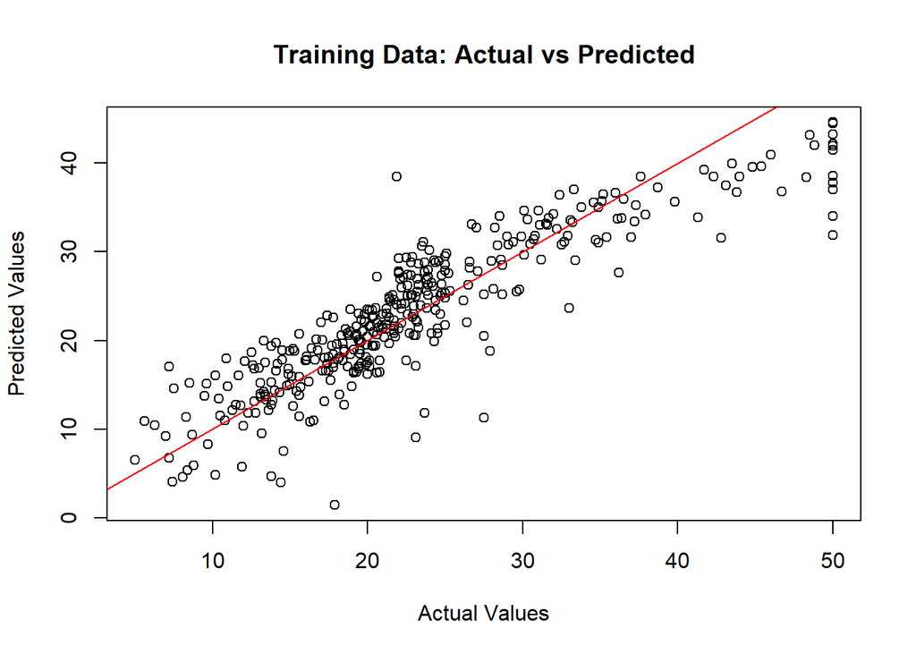

```r
# Plot training predictions vs actual values
plot(train_data$medv, train_predictions, main = "Training Data: Actual vs Predicted",
     xlab = "Actual Values", ylab = "Predicted Values")
abline(0, 1, col = "red")
```

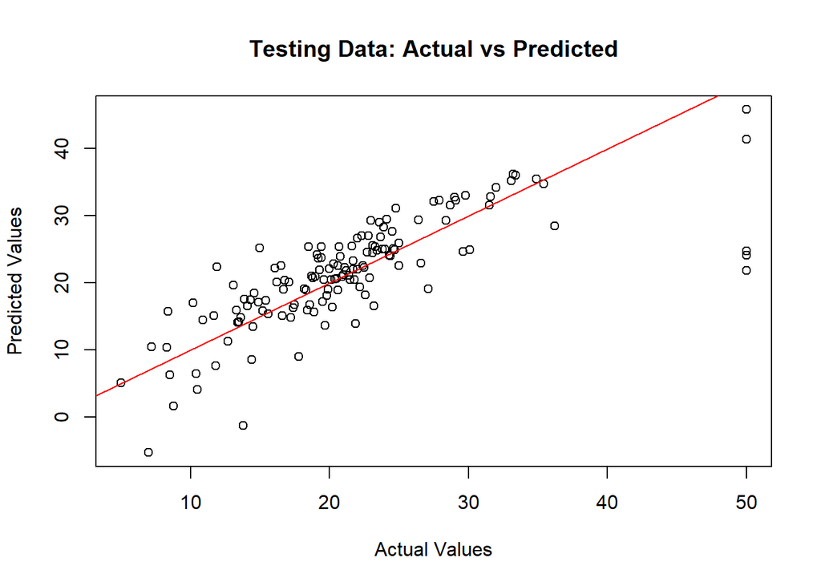

```r
# Plot testing predictions vs actual values
plot(test_data$medv, test_predictions, main = "Testing Data: Actual vs Predicted",
     xlab = "Actual Values", ylab = "Predicted Values")
abline(0, 1, col = "red")
```